# F4: Proyecto Final Integrador

**Proyecto:** Optimización del OEE mediante mantenimiento predictivo inteligente en activos críticos industriales  
**Asignatura:** Programación para Ciencia de Datos  
**Fase:** Sumativa 4 - Integración final  
**Grupo:** Grupo 7

Este notebook consolida el desarrollo técnico realizado durante las fases F1, F2, F3 y F4, integrando definición del problema, preparación de datos, diseño algorítmico, validación técnica, programación orientada a objetos, visualización analítica, trazabilidad y reflexión final.

El foco del proyecto se relaciona con el análisis de eventos de falla en activos industriales. Aunque el OEE se utiliza como marco estratégico, este notebook no calcula formalmente el OEE completo, ya que no se dispone de todas las variables requeridas para estimar disponibilidad, rendimiento y calidad. El análisis desarrollado se vincula principalmente con señales asociadas a disponibilidad operacional.

## Índice

I. Introducción y contextualización

II. Definición de la problemática y objetivos

III. Aplicación de herramientas científicas y reproducibilidad

IV. Diseño de soluciones algorítmicas eficientes  
4.1. Codificación funcional y arquitectura  
4.2. Preprocesamiento y transformación del dataset  
4.3. Validación técnica y verificación del código  
4.4. Eficiencia y optimización: benchmarks con `timeit`  
4.5. Diseño estructurado y recursividad

V. Implementación de código modular y robusto mediante POO

VI. Construcción de visualizaciones de datos efectivas

VII. Metodología, trazabilidad de mejoras y `changelog`

VIII. Resultados y discusión

IX. Conclusiones y reflexión crítica

X. Bibliografía en formato APA 7

## I. Introducción y contextualización

La gestión de activos industriales críticos requiere anticipar eventos de falla que puedan afectar la continuidad operacional, la disponibilidad de equipos y la eficiencia del proceso productivo. En este contexto, el mantenimiento predictivo permite utilizar datos históricos y métricas operacionales para identificar señales tempranas de comportamiento anómalo.

El proyecto se orienta al análisis de un dataset de mantenimiento predictivo compuesto por registros temporales, identificadores de dispositivos, una variable objetivo de falla (`failure`) y métricas operacionales representadas como sensores o variables de condición (`metric1`, `metric2`, etc.). A partir de estos datos, las fases previas permitieron definir la problemática, limpiar y transformar el dataset, implementar soluciones algorítmicas, validar código y construir una arquitectura modular.

La Fase 4 consolida el trabajo transversal mediante un notebook integrador que conecta la definición del problema, el dataset procesado, el núcleo algorítmico, la arquitectura orientada a objetos y un conjunto de visualizaciones analíticas. Las nuevas visualizaciones permiten comunicar patrones relevantes asociados a eventos de falla, distribución de métricas operacionales, desbalance de la variable objetivo y relaciones entre sensores.

Es importante precisar que el proyecto no calcula formalmente el OEE completo, ya que no se dispone de todas las variables necesarias para estimar disponibilidad, rendimiento y calidad. Sin embargo, el análisis se vincula directamente con la dimensión de disponibilidad operacional, dado que los eventos de falla afectan la continuidad productiva y pueden reducir el desempeño global de los activos.

## II. Definición de la problemática y objetivos

### Problemática

Las fallas en activos industriales suelen ser eventos poco frecuentes, pero de alto impacto operacional. Su ocurrencia puede generar detenciones no planificadas, pérdida de disponibilidad, incremento de costos de mantenimiento y reducción de la eficiencia del proceso productivo. Desde una perspectiva de ciencia de datos, este tipo de problema presenta desafíos particulares: desbalance extremo de clases, alta variabilidad en las métricas operacionales y dificultad para explicar las fallas mediante una sola variable aislada.

En el dataset analizado, la variable objetivo `failure` representa la ocurrencia o no ocurrencia de una falla. La baja proporción de eventos positivos confirma que se trata de un fenómeno de eventos raros. Esto obliga a interpretar los resultados con cautela y a considerar, en etapas futuras de modelamiento, métricas distintas a Accuracy, tales como Recall, Precision y F1-Score.

### Objetivo general

Diseñar e implementar un flujo analítico reproducible en Python para estudiar eventos de falla en activos industriales críticos, integrando preprocesamiento, validación técnica, análisis algorítmico, arquitectura modular y visualizaciones orientadas a la comunicación de resultados.

### Objetivos específicos

- Consolidar un dataset procesado, validado y trazable para análisis posterior.
- Implementar componentes funcionales y orientados a objetos que organicen el flujo de análisis.
- Evaluar la eficiencia de soluciones algorítmicas mediante mediciones reproducibles con `timeit`.
- Construir visualizaciones analíticas que permitan interpretar el desbalance de fallas, la distribución de métricas y la relación entre sensores.
- Comunicar hallazgos técnicos de forma clara para apoyar futuras decisiones de mantenimiento predictivo.
- Declarar explícitamente los límites del análisis respecto al cálculo formal del OEE.

## III. Aplicación de herramientas científicas y reproducibilidad

El proyecto utiliza el ecosistema científico de Python como base para asegurar trazabilidad, reproducibilidad y comunicación técnica. Pandas se emplea para la carga, validación y transformación del dataset; NumPy apoya operaciones numéricas; Matplotlib y Seaborn permiten construir visualizaciones analíticas; Jupyter Notebook integra código, resultados y narrativa; y Git/GitHub documentan la evolución del trabajo mediante ramas, commits y Pull Requests.

La reproducibilidad se sostiene mediante rutas relativas, estructura organizada del repositorio, archivo `requirements.txt`, dataset procesado versionado y ejecución completa del notebook mediante `Restart & Run All`. De esta forma, el flujo puede ser revisado por un tercero sin depender de rutas absolutas ni configuraciones locales no documentadas.

```python
import pandas as pd
import numpy as np

class Preprocesador:
    """Clase derivada encargada de aplicar procesos de limpieza y transformación de datos."""
    def __init__(self, df):
        self._df = df.copy()

    def obtener_datos(self):
        return self._df

class Transformador(Preprocesador):
    """Clase derivada encargada de aplicar procesos de limpieza y transformación de datos."""
    def __init__(self, df):
        super().__init__(df)

    def imputar_nulos(self):
        self._df = self._df.dropna()
        return self

    def escalar_minmax(self, columna):
        val_min = self._df[columna].min()
        val_max = self._df[columna].max()
        if val_max != val_min:
            self._df[columna] = (self._df[columna] - val_min) / (val_max - val_min)
        return self
```

## IV. Diseño de soluciones algorítmicas eficientes

El proyecto incorpora soluciones algorítmicas que permiten organizar, transformar y validar los datos de manera estructurada. Durante la Fase 3 se implementaron procedimientos de ordenamiento, comparación de eficiencia y validación de resultados, integrando principios de programación funcional, recursividad y análisis de complejidad.

### 4.1. Codificación funcional y arquitectura

La codificación funcional se aplica mediante funciones específicas para cargar datos, validar columnas, transformar variables, generar resúmenes y preparar subconjuntos para visualización. Esta separación de responsabilidades evita duplicación de código y facilita la trazabilidad del flujo analítico.

### 4.2. Preprocesamiento y transformación del dataset

El dataset procesado proviene de la Fase 2, donde se realizaron acciones de limpieza, eliminación de duplicados, conversión de fechas, creación de variables temporales y validación de estructura. En Fase 4 se reutiliza este dataset como fuente única de análisis, evitando alterar nuevamente la base procesada. Para algunas visualizaciones se aplica la transformación `log1p`, útil para reducir el efecto de valores extremos y mejorar la interpretación gráfica de métricas con alta dispersión.

### 4.3. Validación técnica y verificación del código

La validación técnica se realiza mediante comprobaciones de columnas requeridas, verificación de dataset no vacío, validación de la variable binaria `failure` y control de identificadores de dispositivo. Estos controles permiten detectar errores antes de generar resultados o visualizaciones.

### 4.4. Eficiencia y optimización: benchmarks con `timeit`

En la Fase 3 se comparó el algoritmo `merge_sort` implementado manualmente con la función nativa `sorted()` de Python, utilizando mediciones reproducibles con `timeit`. Aunque ambos enfoques tienen complejidad esperada `O(n log n)`, la función nativa resulta más eficiente en la práctica debido a su optimización interna. Esta comparación permite comprender la diferencia entre complejidad teórica y rendimiento real de implementación.

### 4.5. Diseño estructurado y recursividad

El diseño recursivo de `merge_sort` permitió aplicar conceptos de caso base, división del problema y combinación de resultados. Aunque no es la alternativa más eficiente frente a funciones nativas optimizadas, su implementación tiene valor académico porque evidencia comprensión de estructuras algorítmicas, modularidad y análisis de complejidad.

## V. Implementación de código modular y robusto mediante POO

La programación orientada a objetos se utiliza para organizar el flujo técnico en componentes reutilizables y verificables. Las clases implementadas permiten encapsular datos, aplicar transformaciones, validar resultados y estructurar el análisis de manera más robusta que una secuencia de instrucciones aisladas.

En las fases previas se incorporaron clases como `Preprocesador`, `Transformador` y componentes de pipeline para organizar las etapas de carga, transformación y validación. En Fase 4, la lógica de visualización se fortalece mediante clases como `VisualizadorF4` y `VisualizadorAnaliticoF4`, responsables de cargar el dataset procesado, validar su estructura, preparar variables auxiliares y generar gráficos interpretables.

Esta arquitectura mejora la mantenibilidad del notebook, reduce dependencia de celdas sueltas, permite reutilizar métodos y facilita futuras extensiones hacia modelos predictivos supervisados.

```python
import pandas as pd
import numpy as np

# ==========================================
# Validación de Programación Orientada a Objetos
# ==========================================

df_prueba = pd.DataFrame({
    "temperatura": [50, 60, 70, np.nan]
})

transformador = Transformador(df_prueba)

transformador.imputar_nulos()
transformador.escalar_minmax("temperatura")

print("Validación POO completada correctamente")
print(transformador.obtener_datos())
```

```
Validación POO completada correctamente
   temperatura
0          0.0
1          0.5
2          1.0
```

### Validación de estructura, integración y coherencia entre fases

La validación de estructura comprueba la correcta organización de los componentes correspondientes a F1, F2, F3 y F4. La validación de integración verifica el funcionamiento de las clases desarrolladas mediante Programación Orientada a Objetos, considerando encapsulamiento de datos, transformación de información y ejecución de métodos.

La coherencia entre fases se observa en la continuidad metodológica del proyecto: F1 define el problema industrial, F2 prepara el dataset procesado, F3 incorpora algoritmos, validaciones y POO, y F4 integra estos elementos en una narrativa analítica con visualizaciones y resultados interpretables.

## VI. Construcción de visualizaciones de datos efectivas

Las visualizaciones se construyen con un enfoque de storytelling con datos. Cada gráfico responde una pregunta analítica concreta: si existe desbalance en la variable objetivo, cómo se distribuyen las métricas operacionales, si las fallas se concentran en zonas específicas de sensores, si una métrica cambia entre operación normal y falla, y si existen relaciones o redundancias entre sensores.

El set de visualizaciones permite mostrar que el problema presenta tres características relevantes: eventos de falla poco frecuentes, alta dispersión en las métricas y necesidad de análisis multivariable. Estos elementos justifican que futuras etapas predictivas no se evalúen solo con Accuracy, sino también con métricas como Recall, Precision y F1-Score.

```
Dataset cargado desde: ..\data\processed\dataset_procesado.csv
Total registros analizados: 124493
Total eventos de falla: 106
Total dispositivos únicos: 1169
```

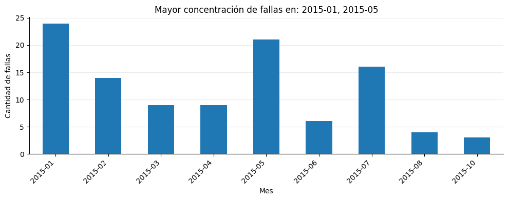

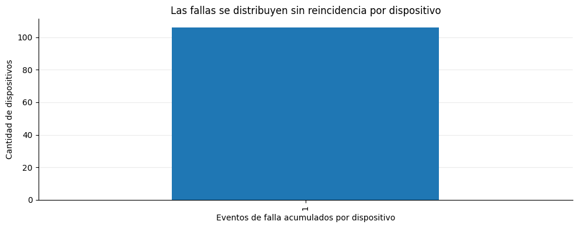

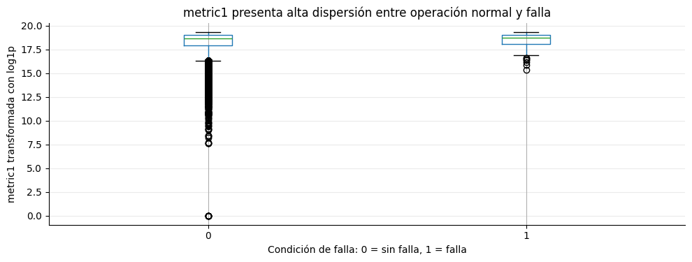

```python
import pandas as pd
import numpy as np
import matplotlib.pyplot as plt
from pathlib import Path


class VisualizadorF4:
    """
    Clase responsable de cargar, validar y preparar datos para las visualizaciones
    analíticas de la Fase 4 del proyecto integrador.
    """

    def __init__(self):
        self._df = self._cargar_dataset()
        self._validar_dataset()

    def _cargar_dataset(self):
        rutas_posibles = [
            Path("data/processed/dataset_procesado.csv"),
            Path("../data/processed/dataset_procesado.csv")
        ]

        for ruta in rutas_posibles:
            if ruta.exists():
                df = pd.read_csv(ruta, parse_dates=["date"])
                print(f"Dataset cargado desde: {ruta}")
                return df

        raise FileNotFoundError(
            "No se encontró el archivo data/processed/dataset_procesado.csv. "
            "Ejecutar primero la Fase 2 o verificar la estructura del repositorio."
        )

    def _validar_dataset(self):
        columnas_requeridas = {"date", "device", "failure", "metric1"}
        faltantes = columnas_requeridas - set(self._df.columns)

        if faltantes:
            raise ValueError(f"Faltan columnas requeridas para F4: {faltantes}")

        assert not self._df.empty, "El dataset no debe estar vacío."
        assert self._df["failure"].isin([0, 1]).all(), "La variable failure debe ser binaria."
        assert self._df["device"].notna().all(), "Existen dispositivos sin identificador."

    def obtener_datos(self):
        return self._df.copy()

    def resumen_base(self):
        return {
            "Total registros analizados": len(self._df),
            "Total eventos de falla": int(self._df["failure"].sum()),
            "Total dispositivos únicos": int(self._df["device"].nunique())
        }

    def fallas_por_mes(self):
        df_fallas = self._df[self._df["failure"] == 1].copy()

        return (
            df_fallas
            .assign(mes=df_fallas["date"].dt.to_period("M").astype(str))
            .groupby("mes")
            .size()
            .sort_index()
        )

    def fallas_por_dispositivo(self):
        return (
            self._df[self._df["failure"] == 1]
            .groupby("device")
            .size()
            .sort_values(ascending=False)
        )

    def distribucion_reincidencia(self):
        return (
            self.fallas_por_dispositivo()
            .value_counts()
            .sort_index()
        )

    def datos_metric1_log(self):
        df_temp = self._df.copy()
        df_temp["metric1_log"] = np.log1p(df_temp["metric1"])
        return df_temp


def limpiar_ejes(ax):
    """
    Reduce ruido visual en los gráficos.
    """
    ax.spines["top"].set_visible(False)
    ax.spines["right"].set_visible(False)
    ax.grid(axis="y", alpha=0.25)
    ax.set_axisbelow(True)
    return ax


# Instancia principal de visualización
visualizador = VisualizadorF4()
df = visualizador.obtener_datos()

# Resumen de control
resumen = visualizador.resumen_base()
for clave, valor in resumen.items():
    print(f"{clave}: {valor}")


# Visualización 1: evolución temporal de eventos de falla
fallas_mes = visualizador.fallas_por_mes()
meses_top = ", ".join(fallas_mes.sort_values(ascending=False).head(2).index)

fig, ax = plt.subplots(figsize=(10, 4))
fallas_mes.plot(kind="bar", ax=ax)

ax.set_title(f"Mayor concentración de fallas en: {meses_top}")
ax.set_xlabel("Mes")
ax.set_ylabel("Cantidad de fallas")
plt.xticks(rotation=45, ha="right")
limpiar_ejes(ax)
plt.tight_layout()
plt.show()


# Visualización 2: recurrencia de fallas por dispositivo
fallas_dispositivo = visualizador.fallas_por_dispositivo()
max_fallas_dispositivo = fallas_dispositivo.max()

fig, ax = plt.subplots(figsize=(10, 4))

if max_fallas_dispositivo <= 1:
    distribucion = visualizador.distribucion_reincidencia()
    distribucion.plot(kind="bar", ax=ax)

    ax.set_title("Las fallas se distribuyen sin reincidencia por dispositivo")
    ax.set_xlabel("Eventos de falla acumulados por dispositivo")
    ax.set_ylabel("Cantidad de dispositivos")
else:
    fallas_dispositivo.head(10).plot(kind="bar", ax=ax)

    ax.set_title("Pocos dispositivos concentran eventos de falla recurrentes")
    ax.set_xlabel("Dispositivo")
    ax.set_ylabel("Total de fallas")
    plt.xticks(rotation=45, ha="right")

limpiar_ejes(ax)
plt.tight_layout()
plt.show()


# Visualización 3: comparación de metric1 según condición de falla
df_metric1 = visualizador.datos_metric1_log()

fig, ax = plt.subplots(figsize=(10, 4))
df_metric1.boxplot(column="metric1_log", by="failure", ax=ax)

plt.suptitle("")
ax.set_title("metric1 presenta alta dispersión entre operación normal y falla")
ax.set_xlabel("Condición de falla: 0 = sin falla, 1 = falla")
ax.set_ylabel("metric1 transformada con log1p")

limpiar_ejes(ax)
plt.tight_layout()
plt.show()
```

### Interpretación de visualizaciones analíticas orientadas al negocio

Las primeras visualizaciones permiten revisar la evolución temporal de fallas, la recurrencia por dispositivo y la distribución de `metric1` según condición de falla.

El análisis temporal muestra que los eventos de falla no se distribuyen de manera completamente uniforme en el período observado. La concentración mensual permite identificar ventanas de mayor criticidad operacional y orientar futuras revisiones de mantenimiento.

La visualización de recurrencia por dispositivo evidencia que los eventos de falla se distribuyen sin reincidencia relevante en un mismo activo. Por tanto, no corresponde interpretar este resultado como un ranking de criticidad individual. La priorización futura debe considerar variables adicionales como severidad, impacto operacional, tiempo de detención, costo asociado y criticidad del activo.

La comparación de `metric1` entre registros con falla y sin falla muestra dispersión y posibles valores extremos. Esto sugiere que una métrica aislada puede aportar información exploratoria, pero no es suficiente para explicar por sí sola la ocurrencia de fallas.

### Visualizaciones analíticas avanzadas

Para fortalecer el análisis visual, se incorpora un set complementario de gráficos alineados con las recomendaciones del curso:

1. Gráfico de barras de la variable objetivo `failure`.
2. Histograma con curva de densidad Kernel.
3. Scatter plot con codificación de color por condición de falla.
4. Gráfico de violín.
5. Matriz de correlación o heatmap.

Estas visualizaciones permiten analizar desbalance de clases, comportamiento de sensores, dispersión, posibles outliers, separación entre estados operacionales y relaciones entre métricas.

```
Dataset cargado desde: ..\data\processed\dataset_procesado.csv
Resumen de control para visualizaciones avanzadas:
- Total registros analizados: 124493
- Total eventos de falla: 106
- Total registros sin falla: 124387
- Total dispositivos únicos: 1169
- Métricas numéricas detectadas: metric1, metric2, metric3, metric4, metric5, metric6, metric7, metric8, metric9
```

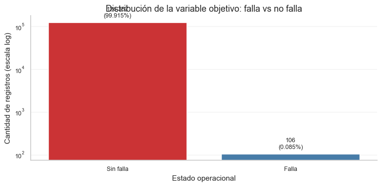

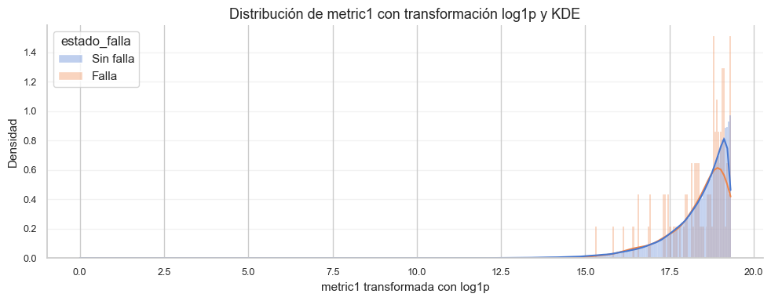

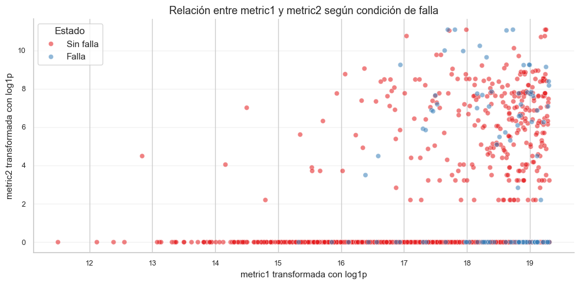

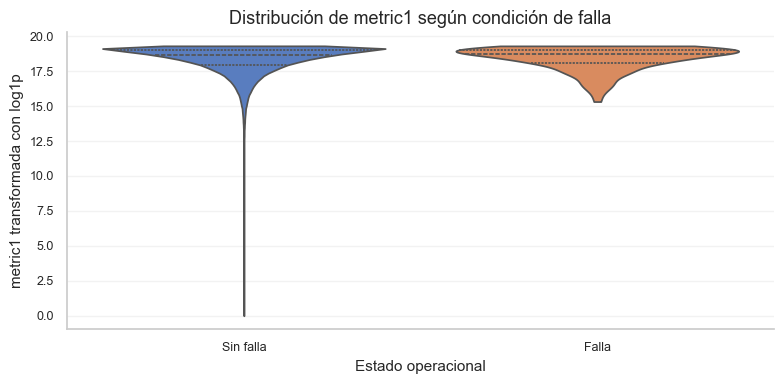

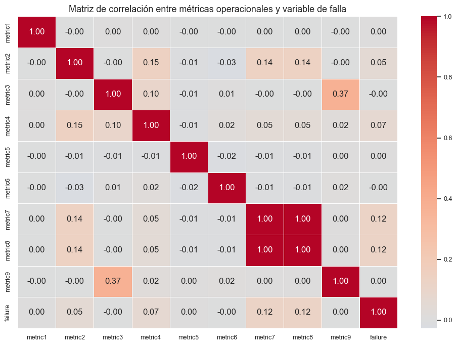

```python
import pandas as pd
import numpy as np
import matplotlib.pyplot as plt
import seaborn as sns
from pathlib import Path

# ============================================================
# Configuración visual según lineamientos de la guía
# ============================================================

sns.set_theme(style="whitegrid", context="notebook")
plt.rcParams.update({
    "figure.figsize": (10, 4),
    "axes.titlesize": 13,
    "axes.labelsize": 11,
    "xtick.labelsize": 9,
    "ytick.labelsize": 9
})


class VisualizadorAnaliticoF4:
    """
    Clase responsable de cargar, validar y preparar datos para las
    visualizaciones analíticas avanzadas de la Fase 4.
    """

    def __init__(self):
        self._df = self._cargar_dataset()
        self._validar_dataset()
        self._metricas = self._detectar_metricas()
        self._preparar_variables()

    def _cargar_dataset(self):
        rutas_posibles = [
            Path("data/processed/dataset_procesado.csv"),
            Path("../data/processed/dataset_procesado.csv")
        ]

        for ruta in rutas_posibles:
            if ruta.exists():
                df = pd.read_csv(ruta, parse_dates=["date"])
                print(f"Dataset cargado desde: {ruta}")
                return df

        raise FileNotFoundError(
            "No se encontró data/processed/dataset_procesado.csv. "
            "Verificar que el dataset procesado de Fase 2 exista en el repositorio."
        )

    def _validar_dataset(self):
        columnas_requeridas = {"date", "device", "failure", "metric1"}
        faltantes = columnas_requeridas - set(self._df.columns)

        if faltantes:
            raise ValueError(f"Faltan columnas requeridas para Fase 4: {faltantes}")

        assert not self._df.empty, "El dataset no debe estar vacío."
        assert self._df["failure"].isin([0, 1]).all(), "La variable failure debe ser binaria."
        assert self._df["device"].notna().all(), "Existen dispositivos sin identificador."

    def _detectar_metricas(self):
        metricas = [
            col for col in self._df.columns
            if col.startswith("metric") and pd.api.types.is_numeric_dtype(self._df[col])
        ]

        if len(metricas) == 0:
            raise ValueError("No se detectaron columnas numéricas tipo metric.")

        return metricas

    def _preparar_variables(self):
        self._df["estado_falla"] = self._df["failure"].map({
            0: "Sin falla",
            1: "Falla"
        })

        self._df["estado_falla"] = pd.Categorical(
            self._df["estado_falla"],
            categories=["Sin falla", "Falla"],
            ordered=True
        )

    @staticmethod
    def _log1p_seguro(serie):
        serie = pd.to_numeric(serie, errors="coerce")
        minimo = serie.min(skipna=True)

        if pd.notna(minimo) and minimo < 0:
            serie = serie - minimo

        return np.log1p(serie)

    @staticmethod
    def _limpiar_ejes(ax):
        ax.spines["top"].set_visible(False)
        ax.spines["right"].set_visible(False)
        ax.grid(axis="y", alpha=0.25)
        ax.set_axisbelow(True)
        return ax

    def resumen(self):
        return {
            "Total registros analizados": len(self._df),
            "Total eventos de falla": int(self._df["failure"].sum()),
            "Total registros sin falla": int((self._df["failure"] == 0).sum()),
            "Total dispositivos únicos": int(self._df["device"].nunique()),
            "Métricas numéricas detectadas": ", ".join(self._metricas)
        }

    # ============================================================
    # 1. Gráfico de barras de distribución de variable objetivo
    # ============================================================

    def grafico_variable_objetivo(self):
        conteo = (
            self._df["estado_falla"]
            .value_counts()
            .reindex(["Sin falla", "Falla"], fill_value=0)
        )

        datos = conteo.rename_axis("Estado").reset_index(name="Registros")
        datos["Porcentaje"] = datos["Registros"] / len(self._df) * 100

        fig, ax = plt.subplots(figsize=(8, 4))

        sns.barplot(
            data=datos,
            x="Estado",
            y="Registros",
            palette="Set1",
            ax=ax
        )

        ax.set_title("Distribución de la variable objetivo: falla vs no falla")
        ax.set_xlabel("Estado operacional")
        ax.set_ylabel("Cantidad de registros")

        # Escala logarítmica para que la clase minoritaria sea visible
        if (datos["Registros"] > 0).all():
            ax.set_yscale("log")
            ax.set_ylabel("Cantidad de registros (escala log)")

        for barra, (_, fila) in zip(ax.patches, datos.iterrows()):
            altura = barra.get_height()
            ax.annotate(
                f"{int(fila['Registros']):,}\n({fila['Porcentaje']:.3f}%)",
                xy=(barra.get_x() + barra.get_width() / 2, altura),
                xytext=(0, 5),
                textcoords="offset points",
                ha="center",
                va="bottom",
                fontsize=9
            )

        self._limpiar_ejes(ax)
        plt.tight_layout()
        plt.show()

    # ============================================================
    # 2. Histograma con KDE
    # ============================================================

    def grafico_histograma_kde(self, metrica="metric1"):
        if metrica not in self._metricas:
            metrica = self._metricas[0]

        df_plot = self._df[[metrica, "estado_falla"]].dropna().copy()
        metrica_log = f"{metrica}_log1p"
        df_plot[metrica_log] = self._log1p_seguro(df_plot[metrica])

        fig, ax = plt.subplots(figsize=(10, 4))

        sns.histplot(
            data=df_plot,
            x=metrica_log,
            hue="estado_falla",
            kde=True,
            stat="density",
            common_norm=False,
            palette="muted",
            alpha=0.35,
            ax=ax
        )

        ax.set_title(f"Distribución de {metrica} con transformación log1p y KDE")
        ax.set_xlabel(f"{metrica} transformada con log1p")
        ax.set_ylabel("Densidad")

        self._limpiar_ejes(ax)
        plt.tight_layout()
        plt.show()

    # ============================================================
    # 3. Scatter plot con hue
    # ============================================================

    def grafico_scatter_hue(self):
        if len(self._metricas) < 2:
            print("No se genera scatter plot: se requieren al menos dos métricas numéricas.")
            return

        metrica_x = self._metricas[0]
        metrica_y = self._metricas[1]

        df_plot = self._df[[metrica_x, metrica_y, "failure", "estado_falla"]].dropna().copy()

        df_plot[f"{metrica_x}_log1p"] = self._log1p_seguro(df_plot[metrica_x])
        df_plot[f"{metrica_y}_log1p"] = self._log1p_seguro(df_plot[metrica_y])

        # Muestra controlada para evitar sobrecarga visual:
        # se mantienen todas las fallas y se toma muestra de registros sin falla.
        df_falla = df_plot[df_plot["failure"] == 1]
        df_normal = df_plot[df_plot["failure"] == 0].sample(
            n=min(5000, (df_plot["failure"] == 0).sum()),
            random_state=42
        )

        df_scatter = pd.concat([df_normal, df_falla], axis=0)

        fig, ax = plt.subplots(figsize=(10, 5))

        sns.scatterplot(
            data=df_scatter,
            x=f"{metrica_x}_log1p",
            y=f"{metrica_y}_log1p",
            hue="estado_falla",
            palette="Set1",
            alpha=0.55,
            s=35,
            ax=ax
        )

        ax.set_title(f"Relación entre {metrica_x} y {metrica_y} según condición de falla")
        ax.set_xlabel(f"{metrica_x} transformada con log1p")
        ax.set_ylabel(f"{metrica_y} transformada con log1p")
        ax.legend(title="Estado")

        self._limpiar_ejes(ax)
        plt.tight_layout()
        plt.show()

    # ============================================================
    # 4. Gráfico de violín
    # ============================================================

    def grafico_violin(self, metrica="metric1"):
        if metrica not in self._metricas:
            metrica = self._metricas[0]

        df_plot = self._df[[metrica, "estado_falla"]].dropna().copy()
        metrica_log = f"{metrica}_log1p"
        df_plot[metrica_log] = self._log1p_seguro(df_plot[metrica])

        fig, ax = plt.subplots(figsize=(8, 4))

        sns.violinplot(
            data=df_plot,
            x="estado_falla",
            y=metrica_log,
            palette="muted",
            inner="quartile",
            cut=0,
            ax=ax
        )

        ax.set_title(f"Distribución de {metrica} según condición de falla")
        ax.set_xlabel("Estado operacional")
        ax.set_ylabel(f"{metrica} transformada con log1p")

        self._limpiar_ejes(ax)
        plt.tight_layout()
        plt.show()

    # ============================================================
    # 5. Matriz de correlación
    # ============================================================

    def grafico_heatmap_correlacion(self):
        columnas_corr = self._metricas + ["failure"]

        if len(columnas_corr) < 3:
            print("No se genera heatmap: se requieren al menos dos métricas más la variable failure.")
            return

        corr = self._df[columnas_corr].corr(numeric_only=True)

        fig, ax = plt.subplots(figsize=(10, 7))

        sns.heatmap(
            corr,
            annot=True,
            fmt=".2f",
            cmap="coolwarm",
            center=0,
            linewidths=0.5,
            ax=ax
        )

        ax.set_title("Matriz de correlación entre métricas operacionales y variable de falla")
        plt.tight_layout()
        plt.show()


# ============================================================
# Ejecución reproducible del bloque de visualización avanzada
# ============================================================

visualizador_avanzado = VisualizadorAnaliticoF4()

print("Resumen de control para visualizaciones avanzadas:")
for clave, valor in visualizador_avanzado.resumen().items():
    print(f"- {clave}: {valor}")

visualizador_avanzado.grafico_variable_objetivo()
visualizador_avanzado.grafico_histograma_kde(metrica="metric1")
visualizador_avanzado.grafico_scatter_hue()
visualizador_avanzado.grafico_violin(metrica="metric1")
visualizador_avanzado.grafico_heatmap_correlacion()
```

### Interpretación ejecutiva de visualizaciones analíticas avanzadas

**1. Distribución de la variable objetivo `failure`.**  
El gráfico de barras evidencia el desbalance extremo entre registros normales y eventos de falla. Este hallazgo es central, porque demuestra que Accuracy puede ser una métrica engañosa en un futuro modelo predictivo. Un modelo que clasifique casi todo como “sin falla” podría obtener alta exactitud, pero sería poco útil para detectar eventos críticos. Por ello, futuras etapas deberían considerar Recall, Precision y F1-Score.

**2. Histograma con KDE.**  
El histograma con curva de densidad permite analizar la distribución de una métrica operacional. La transformación `log1p` facilita la lectura cuando existen escalas amplias o valores extremos. La presencia de dispersión y asimetrías indica que no se debe asumir normalidad sin revisión previa.

**3. Scatter plot con codificación por color.**  
El gráfico de dispersión permite observar si las fallas se concentran en una zona específica al combinar dos sensores. Si las fallas aparecen dispersas en la nube general, se refuerza la necesidad de un enfoque multivariable más avanzado.

**4. Gráfico de violín.**  
El gráfico de violín compara la distribución de una métrica entre operación normal y falla. Permite observar diferencias de mediana, dispersión y concentración de valores. Si las formas son similares, la métrica no discrimina claramente por sí sola; si son distintas, puede aportar señal para modelos posteriores.

**5. Matriz de correlación.**  
El heatmap permite revisar relaciones lineales entre sensores y detectar posibles redundancias. Si `failure` no presenta una correlación fuerte con una única métrica, se justifica técnicamente la necesidad de modelos que integren varias señales operacionales.

En conjunto, estas visualizaciones confirman que el problema presenta eventos raros, alta variabilidad en métricas operacionales y necesidad de análisis multimétrica.

## VII. Metodología, trazabilidad de mejoras y `changelog`

La metodología de trabajo se estructuró en fases sucesivas, manteniendo continuidad técnica entre la definición del problema, la preparación de datos, el diseño algorítmico y la comunicación visual de resultados.

| Fase | Aporte principal | Evidencia |
| --- | --- | --- |
| F1 | Definición del problema, contexto industrial y entorno base | Carpeta F1, notebook inicial y documentación del problema |
| F2 | Limpieza, transformación y dataset procesado | `data/processed/dataset_procesado.csv` |
| F3 | Algoritmos, recursividad, POO, validaciones y `timeit` | Notebook F3 y documentación técnica |
| F4 | Integración final, visualizaciones, storytelling y cierre crítico | `F4/F4_Proyecto_Final_Integrador.ipynb` |

El archivo `changelog.md` documenta las mejoras incorporadas durante el proyecto, incluyendo ajustes de visualización, actualización de README, integración de carpetas F1-F4, mejoras en la narrativa técnica y exportación del notebook ejecutado como evidencia reproducible.

El uso de Git y GitHub permite mantener trazabilidad mediante ramas, commits y Pull Requests, asegurando control de versiones y revisión del trabajo antes de integrarlo a la rama principal.

## VIII. Resultados y discusión

Los resultados evidencian que el dataset contiene 124.493 registros procesados, 106 eventos de falla y 1.169 dispositivos únicos. La distribución de la variable objetivo confirma un desbalance extremo, característico de problemas de mantenimiento predictivo industrial, donde las fallas son eventos poco frecuentes.

El histograma con KDE y el gráfico de violín muestran que las métricas operacionales presentan alta dispersión y posibles valores extremos, por lo que no resulta recomendable asumir normalidad ni interpretar una única métrica como explicación suficiente de la falla. El scatter plot y la matriz de correlación refuerzan la necesidad de un enfoque multivariable, ya que la ocurrencia de fallas no parece depender exclusivamente de una señal aislada.

Desde una perspectiva de negocio, estos resultados sugieren que una futura solución predictiva debería orientarse a priorizar alertas tempranas, mejorar la disponibilidad operacional y apoyar decisiones de mantenimiento. No obstante, el análisis debe interpretarse como una base exploratoria y metodológica, no como un modelo predictivo productivo ni como un cálculo completo del OEE.

El principal aporte de la Fase 4 es integrar resultados técnicos en una narrativa comunicable. Las visualizaciones no se presentan como elementos decorativos, sino como evidencia para comprender el comportamiento de fallas, justificar decisiones metodológicas y proyectar futuras mejoras analíticas.

## IX. Conclusiones y reflexión crítica

La Sumativa 4 permitió consolidar el proyecto en una versión integradora y reproducible, articulando definición del problema, preparación de datos, diseño algorítmico, programación orientada a objetos y visualizaciones analíticas. El trabajo demuestra que el equipo logró construir un flujo técnico verificable, documentado y alineado con buenas prácticas de ciencia de datos.

Como principal hallazgo, se observa que las fallas son eventos escasos y que las métricas operacionales presentan alta variabilidad. Esto obliga a considerar enfoques multivariables y métricas de evaluación adecuadas en futuras etapas predictivas. La visualización de datos permitió transformar resultados técnicos en evidencia comunicable para la toma de decisiones.

La principal limitación es que el proyecto aún no implementa un modelo predictivo supervisado ni calcula el OEE completo. Para avanzar hacia una solución industrial más robusta, se recomienda incorporar variables operacionales adicionales, estimar componentes formales del OEE, evaluar modelos de clasificación y considerar métricas como Recall, Precision y F1-Score para tratar el desbalance de clases.

Como reflexión crítica, el proyecto evidencia que la calidad de una solución de ciencia de datos no depende solo de ejecutar código, sino de construir un flujo reproducible, interpretar correctamente las limitaciones de los datos y comunicar los hallazgos de forma honesta y útil para la gestión operacional.

## X. Bibliografía en formato APA 7

Agarwal, H. (2020). *Predictive maintenance dataset* [Conjunto de datos]. Kaggle.

Cormen, T. H., Leiserson, C. E., Rivest, R. L., & Stein, C. (2022). *Introduction to algorithms* (4th ed.). MIT Press.

Hunter, J. D. (2007). Matplotlib: A 2D graphics environment. *Computing in Science & Engineering, 9*(3), 90-95.

Knaflic, C. N. (2015). *Storytelling with data: A data visualization guide for business professionals*. Wiley.

McKinney, W. (2022). *Python for data analysis: Data wrangling with pandas, NumPy, and Jupyter* (3rd ed.). O'Reilly Media.

The pandas development team. (2024). *pandas documentation*. https://pandas.pydata.org/docs/

Tufte, E. R. (2001). *The visual display of quantitative information* (2nd ed.). Graphics Press.

Waskom, M. L. (2021). seaborn: Statistical data visualization. *Journal of Open Source Software, 6*(60), 3021.

Python Software Foundation. (s. f.). *Python documentation*. https://docs.python.org/

Project Jupyter. (s. f.). *Project Jupyter documentation*. https://docs.jupyter.org/